# Lab_09T

36-290 – Statistical Research Methodology

Week 9 Tuesday – Fall 2020

Name: Cherie Hua

Andrew ID: cxhua

This lab is to be begun in class, but may be finished outside of class at any time prior to Wednesday, October 28<sup>th</sup> at 6:00 PM. You must commit both the edited `Rmd` file and the “knitted” `html` file for this lab to your `GitHub` repo. (You can verbally discuss aspects of the labs with your classmates, but please do not share code, etc.)

# Preliminaries

## Goal

Today we will apply both regression-tree-style and classification-tree-style boosting to the datasets we began working with last week. (However, instead of using the `gbm` package of ISLR, we will use the newer, fancier `xgboost` package.)

# Questions

## Data, Part I

Below we read in the same data that we used during Week 7. On Tuesday we did not downsample, because tree computations go quickly. On Thursday we did downsample, because random forest calculations go relatively slowly. Today we are back in a situation where downsampling is not necessary, because `xgboost` is fast.

```r
rm(list=ls())
file.path = "https://raw.githubusercontent.com/pefreeman/36-290/master/EXAMPLE_DATASETS/DM_GALAXY/Massive_Black_II.Rdata"
load(url(file.path))
rm(file.path)
objects()
```

```
## [1] "pred.test"     "pred.train"    "resp.test.df"  "resp.train.df"
```

```r
resp.train = resp.train.df$prop.sfr
w = which(resp.train>0)
pred.train = pred.train[w,]
resp.train = log10(resp.train[w])

resp.test  = resp.test.df$prop.sfr
w = which(resp.test>0)
pred.test = pred.test[w,]
resp.test = log10(resp.test[w])

cat("Sample sizes: train = ",length(resp.train)," test = ",length(resp.test),"\n")
```

```
## Sample sizes: train =  61255  test =  30143
```

## Question 1

We will install and use the `xgboost` package. `xgboost` is a newer, pricklier package that doesn’t always do things “the R way.”

First, you will want to use the `xgb.DMatrix()` function to create train and test matrices; the arguments to `xgb.DMatrix()` should be, e.g., `data=as.matrix(pred.train)` and `label=resp.train`. (Note the `as.matrix()` call: `xgboost` does not work with categorical predictor variables!)

Second, you will want to set a random number generator seed and call the function `xgb.cv`, passing in your training data, a number of folds (`nfold`), a maximum number of trees to try (`nrounds`), and a list of parameters (e.g., `params=list(objective="reg:squarederror"))`…all this means evaluate the test-set MSE instead of some other cost function).

Third, you will want to call `xgboost`, passing in your training data and the optimal number of trees. As it is not clear how to get this information: assume your output variable for `xgb.cv()` is simply called `out`. Then the optimal number of trees is given by `which.min(out$evaluation_log$test_rmse_mean)`. Simple, huh? Also input the same `params` argument as above.

Fourth, you want to call `predict()`, with your output from `xgboost` and with `newdata=test`.

Finally: compute the test-set MSE and use `ggplot()` to plot the typical regression diagnostic plot that we use in this class. You should find that the test-set MSE is roughly the same as that for random forest, indicating that boosting doesn’t necessarily buy you better predictions (but: it does make predictions faster, which means you can process more data, so there’s consequently less uncertainty on the predictions and the test-set MSE…and you can more easily perform cross-validation).

Note: if you want to turn off the output from `xgb.cv` and `xgboost`, pass the argument `verbose=0`.

```r
if ( require(xgboost) == FALSE ) {
  install.packages("xgboost",repos="https://cloud.r-project.org")
  library(xgboost)
}
training <- xgb.DMatrix(data = as.matrix(pred.train), label = resp.train)

set.seed(4193)
out <- xgb.cv(data = training, nfold = 5, nrounds = 40, params=list(objective="reg:squarederror"), verbose = 0)

boost <- xgboost(data = training, nrounds = 40, num_parallel_tree = which.min(out$evaluation_log$test_rmse_mean), params=list(objective="reg:squarederror"), verbose = 0)
```

```r
library(GGally)
pred <- predict(boost, newdata = as.matrix(pred.test), n.trees = which.min(out$evaluation_log$test_rmse_mean))
mse <- mean((resp.test - pred)^2)
mse
```

```
## [1] 0.2227118
```

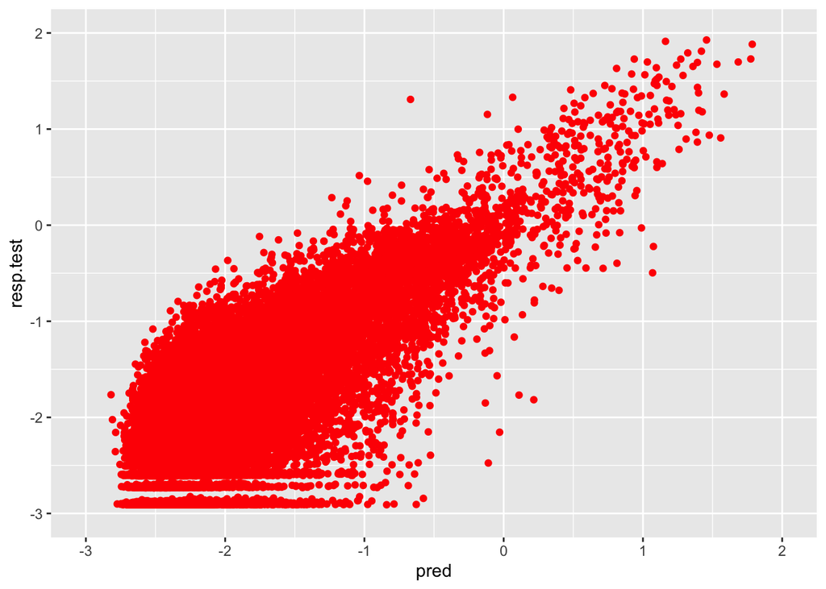

```r
ggplot(mapping = aes(pred, resp.test)) + geom_point(color = "red") + xlim(-3, 2) + ylim(-3, 2)
```

## Question 2

Generate an importance plot given the output from training your `xgboost` model. This involves two steps: a call to `xgb.importance()` and a call to `xgb.plot.importance()`. (Display the output from `xgb.importance()`. Note that the importances match what is in the Gain column of the output.) Check the documentation for each. You should discover that `halos.vdisp` is by far the most important variable.

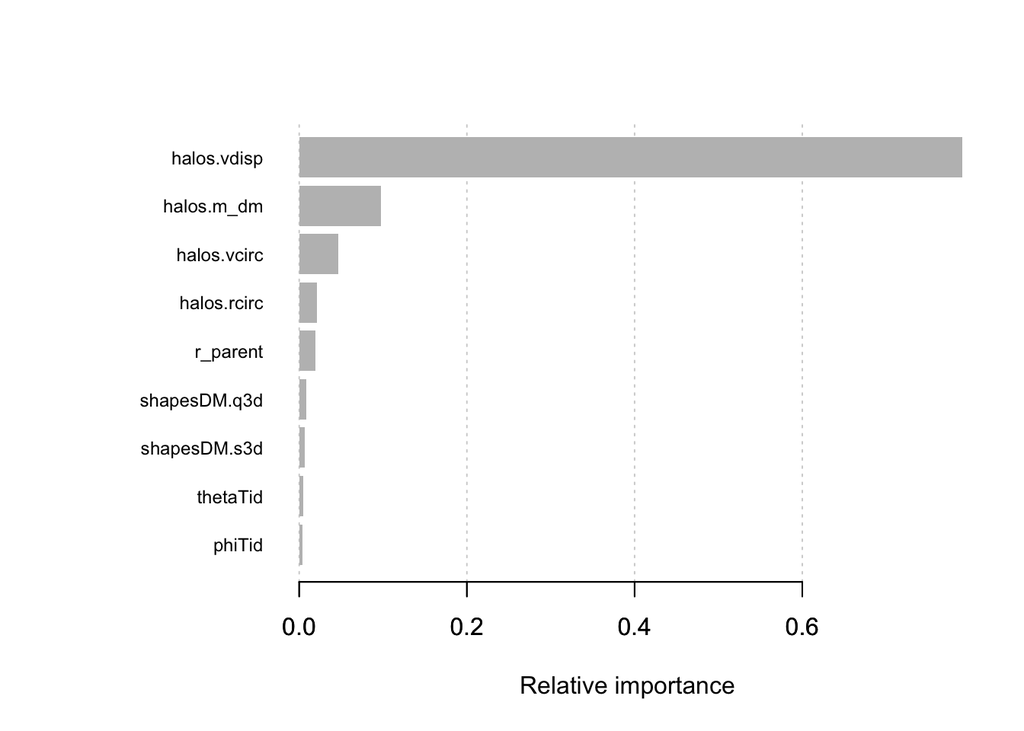

```r
imp <- xgb.importance(model = boost)
xgb.plot.importance(imp, xlab = "Relative importance")
```

Now we turn our attention to classification.

## Data, Part II

We will now load the second dataset from last week: note that while we will not cut down the sample size, we will still balance the classes. Note that `xgboost` wants integer class labels, so I map “CB” to 0 and “NON-CB” to 1.

```r
rm(list=ls())
file.path = "https://raw.githubusercontent.com/pefreeman/36-290/master/EXAMPLE_DATASETS/TD_CLASS/css_data.Rdata"
load(url(file.path))
rm(file.path)

# Eliminate the max.slope column (the 11th column), which has infinities.
predictors = predictors[,-11]

set.seed(404)
w.cb = which(response==1)
w.noncb = which(response!=1)
s = sample(length(w.cb),length(w.noncb))
predictors.cb = predictors[w.cb[s],]
response.cb   = response[w.cb[s]]
predictors.noncb = predictors[w.noncb,]
response.noncb   = response[w.noncb]
predictors = rbind(predictors.cb,predictors.noncb)
response   = c(response.cb,response.noncb)

response.new = rep(0,length(response))
w = which(response!=1)
response.new[w] = 1
response = response.new
cat("Sample size: ",length(response),"\n")
```

```
## Sample size:  32452
```

## Question 3

You know the drill: split the data, then learn an `xgboost` model and output the test-set MCR value and the confusion matrix. Also create a ROC curve, and determine the AUC. The number should be close to what you observed for random forest, meaning it should be better than what you observed for logistic regression. Finally, plot the importances.

A major difference between this question and Q1: here, the objective is “binary:logistic” as opposed to “reg:squarederror”. Also, instead of “test_rmse_mean” as the metric output by `xgb.cv.out`, the metric is now “test_error_mean”.

```r
set.seed(0275)
dt = sample(nrow(predictors), 0.7*nrow(predictors))
pred.train = predictors[dt,]
pred.test = predictors[-dt,]
resp.train = response[dt]
resp.test = response[-dt]

training <- xgb.DMatrix(data = as.matrix(pred.train), label = resp.train)

set.seed(2965)
out <- xgb.cv(data = training, nfold = 5, nrounds = 40, params=list(objective="binary:logistic"), verbose = 0)

boost <- xgboost(data = training, nrounds = 40, num_parallel_tree = which.min(out$evaluation_log$test_error_mean), params=list(objective="binary:logistic"), verbose = 0)
```

```r
set.seed(2894)
pred <- predict(boost, newdata = as.matrix(pred.test), n.trees = which.min(out$evaluation_log$test_error_mean))
mse <- mean((resp.test - pred)^2)
mse
```

```
## [1] 0.1357827
```

```r
table(ifelse(pred < 0.5, "CB", "NON-CB"), resp.test)
```

```
##         resp.test
##             0    1
##   CB     4156 1217
##   NON-CB  685 3678
```

MSE = .1358

```r
library(pROC)
boost.roc <- roc(resp.test, pred)
boost.roc
```

```
##
## Call:
## roc.default(response = resp.test, predictor = pred)
##
## Data: pred in 4841 controls (resp.test 0) < 4895 cases (resp.test 1).
## Area under the curve: 0.8841
```

The AUC is .8841.

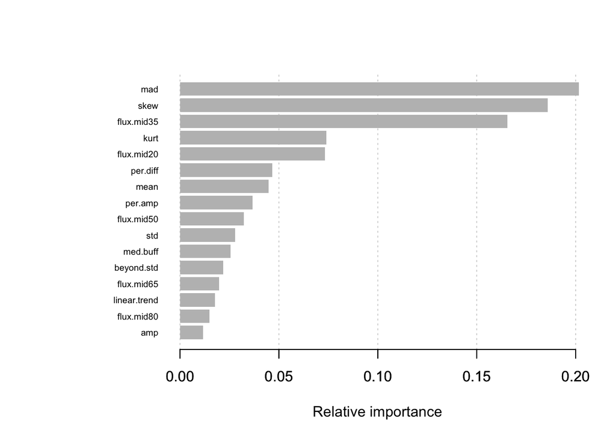

```r
imp <- xgb.importance(model = boost)
xgb.plot.importance(imp, xlab = "Relative importance")
```